# Analysis of Lung Function Decline: Annual 2 years cohort

Weiji Su, Enas Ghulam, Emrah Gecili, Eleni-Rosalina Andrinopoulou, Rhonda Szczesniak

April 18, 2019

# 1 Analysis Cohort

In this analysis, there are 30811 subjects and 63194 observations. Mean (range) of follow-up time per patient was 1 (0, 2) years. Mean (range) number of observations was 2 (1, 3). The same number of patients and observations were utilized in each model below. We assume for each model that the data are missing at random, except for the joint longitudinal-survival model. The dependent variable is GLI FEV1 (% predicted) named “y” in the output below. The time scale is patients’ age at visit. Age is expressed in years. Age at CF diagnosis (in years) was included as a covariate in each model. Below are summary statistics for each variable used in the model. Once a patient was recorded as having a lung transplant, his or her data were censored from the model.

```
##        y                Age        Age_Diag_per_patient
##  Min.   :  9.156   Min.   : 6.00   Min.   :-0.600
##  1st Qu.: 53.218   1st Qu.:10.00   1st Qu.: 0.100
##  Median : 78.609   Median :16.00   Median : 0.400
##  Mean   : 74.069   Mean   :18.45   Mean   : 2.231
##  3rd Qu.: 94.937   3rd Qu.:24.00   3rd Qu.: 2.400
##  Max.   :148.278   Max.   :75.00   Max.   :18.000
```

The Kaplan-Meier (KM) survival curve for those who died or received a lung transplant is plotted below showing the survival probability over age at visit (top graphic) and the number still alive/without lung transplant (bottom graphic).

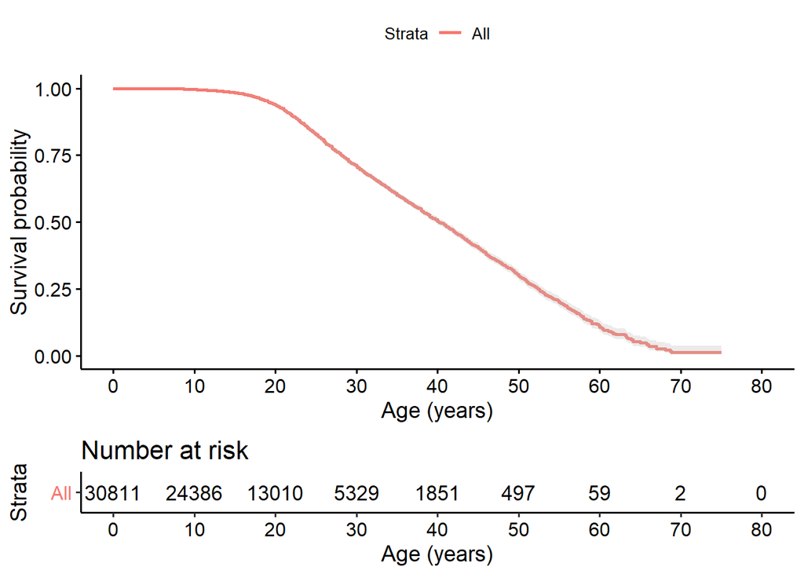

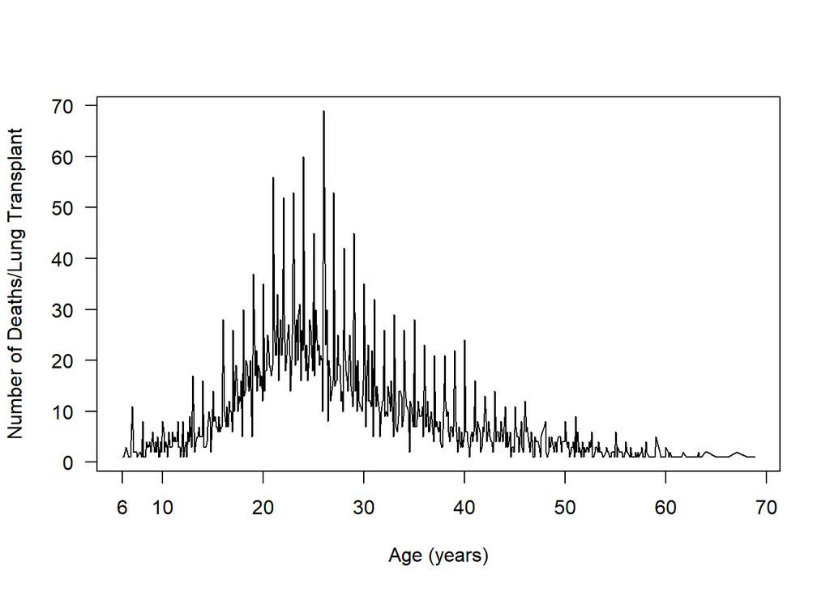

In the following report, we investigate three commonly used structures in CF FEV1 analysis. These include the linear mixed-effects model (LME), Generalized Estimating Equations (GEE) and joint modelling (JM). For the LME models, we include different combinations of random effects, splines and correlation structures as used in published CF studies (Section 2). We examine published GEE models combined with additional features for linearity/non-linearity (Section 3).

# 2 Linear Mixed-Effects Model (LME)

## 2.1 LME Model with Random Intercept

### 2.1.1 Assumptions

Average evolution: A linear evolution is assumed over time.

Patient-specific evolution: A linear evolution is assumed over time. We assume that each patient may start from a different time point but all patients have the same evolution over time.

### 2.1.2 Model Estimation

```
## [1] "AIC =  513565"
```

```
## [1] "BIC =  513610"
```

Variance Components

|  | StdDev |
| --- | --- |
| (Intercept) | 21.529330 |
| Residual | 6.638617 |

|  | Value | Std.Error | DF | t-value | p-value |
| --- | --- | --- | --- | --- | --- |
| (Intercept) | 97.748 | 0.248 | 32382 | 393.872 | 0 |
| Age | -1.353 | 0.012 | 32382 | -115.654 | 0 |
| Age_Diag | 0.608 | 0.033 | 30809 | 18.235 | 0 |

As the coefficient estimate for ‘Age’ is around -1.353 % predicted/year, this means for one year increase in age, FEV1 is decreasing by 1.353 (unit % predicted).

### 2.1.3 Model Inference

We can calculate the population-level evolution (left) and rate of change (right) over time. As we have assumed a linear evolution, the left figure shows a straight line, corresponding to a linear estimated fit. The rate of change is calculated by taking first derivative of the model equation over time. This model estimates the rate of change in FEV1 as constant over different ages as -1.353.

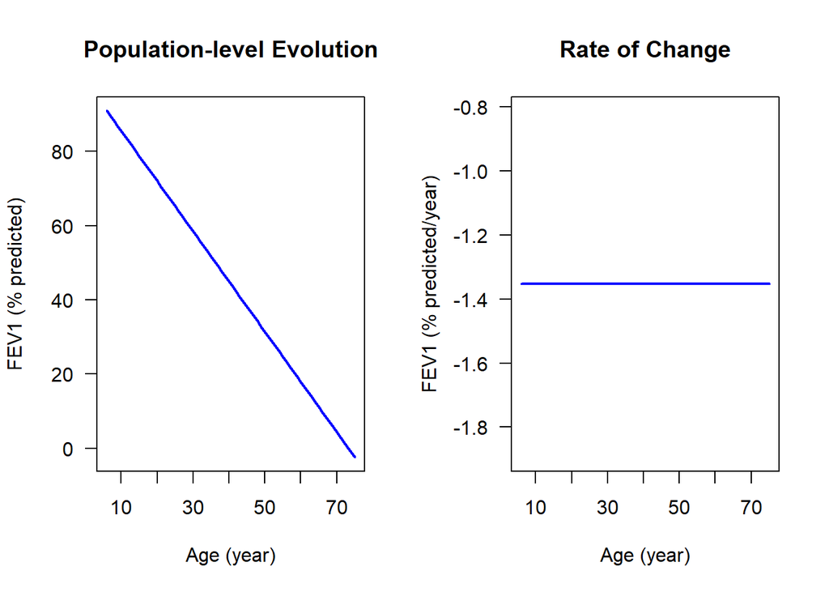

### 2.1.4 Model Diagnostics

We examined standardized residuals in terms of randomness, spread and nature of distribution.

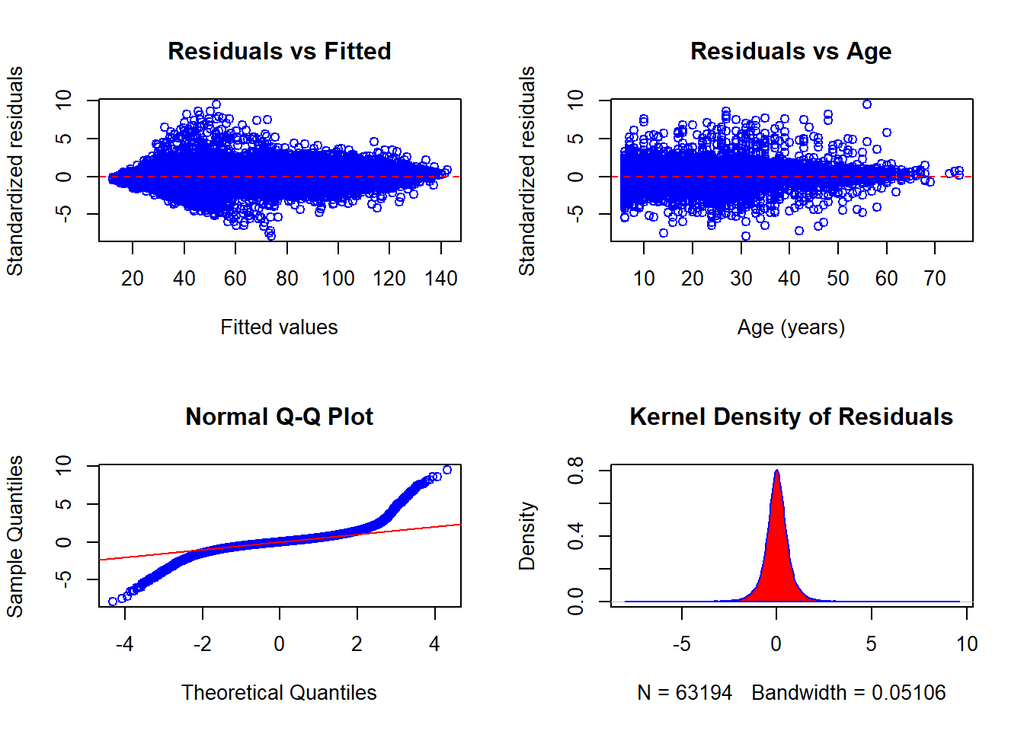

## 2.2 LME Model with Random Intercept and Slope

### 2.2.1 Assumptions

Average evolution: A linear evolution is assumed over time.

Patient-specific evolution: A linear evolution is assumed over time. We assume that each patient may start from a different time point but all patients have different evolution over time.

### 2.2.2 Model Estimation

```
## [1] "AIC =  512918"
```

```
## [1] "BIC =  512982"
```

Variance Components

|  | StdDev |
| --- | --- |
| (Intercept) | 17.0042634 |
| Age | 0.2979526 |
| Residual | 6.6319072 |

|  | Value | Std.Error | DF | t-value | p-value |
| --- | --- | --- | --- | --- | --- |
| (Intercept) | 99.655 | 0.240 | 32382 | 415.007 | 0 |
| Age | -1.460 | 0.013 | 32382 | -113.685 | 0 |
| Age_Diag | 0.628 | 0.034 | 30809 | 18.372 | 0 |

As the estimation of coefficient for ‘Age’ is around -1.46 % predicted/year, this means for one year increase in age, FEV1 is decreasing by 1.46 (unit % predicted).

### 2.2.3 Model Inference

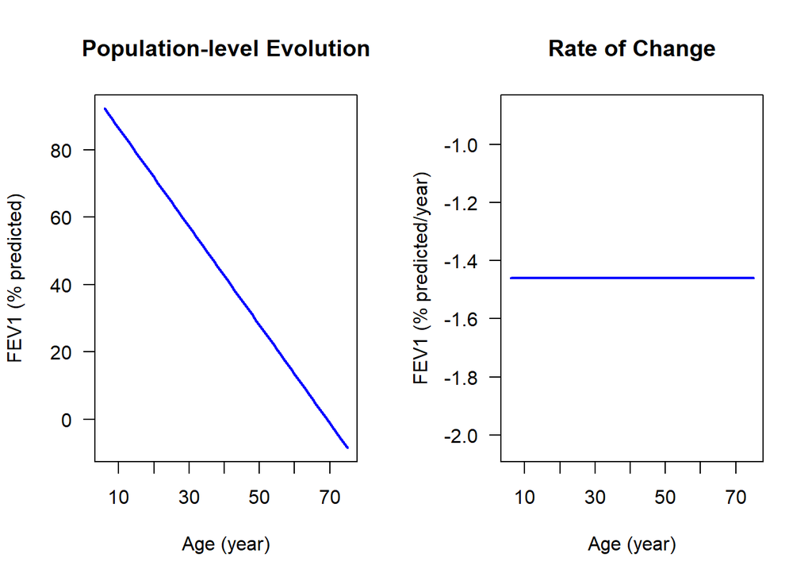

### 2.2.4 Model Diagnostics

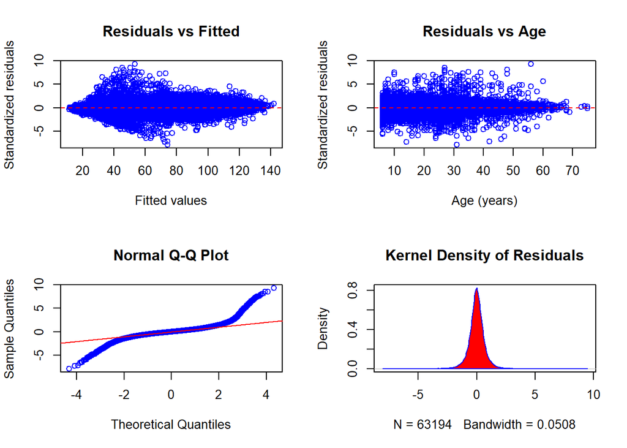

The model diagnostic plots are below and they are similar to the previous pattern.

## 2.3 LME Model with 5-knot Natural Spline

### 2.3.1 Assumptions

Average evolution: A non-linear evolution (assuming cubic natural splines) is assumed over time.

Patient-specific evolution: A non-linear evolution (assuming cubic natural splines) is assumed over time. A diagonal variance-covariance matrix for the random effects are assumed. This means that the random effects are not correlated.

```
## [1] "Knots location (at age): 9.8, 13.5, 17.3, 21.4, 31.3"
```

### 2.3.2 Model Estimation

```
## [1] "AIC =  510636"
```

```
## [1] "BIC =  510781"
```

Variance Components

|  | StdDev |
| --- | --- |
| (Intercept) | 17.050553 |
| ns1 | 13.022421 |
| ns2 | 20.333820 |
| ns3 | 22.075948 |
| ns4 | 27.194597 |
| ns5 | 7.084215 |
| ns6 | 20.901853 |
| Residual | 6.195362 |

|  | Value | Std.Error | DF | t-value | p-value |
| --- | --- | --- | --- | --- | --- |
| (Intercept) | 91.455 | 0.240 | 32377 | 381.480 | 0 |
| ns1 | -13.670 | 0.427 | 32377 | -31.978 | 0 |
| ns2 | -17.787 | 0.474 | 32377 | -37.551 | 0 |
| ns3 | -35.247 | 0.515 | 32377 | -68.405 | 0 |
| ns4 | -44.372 | 1.147 | 32377 | -38.699 | 0 |
| ns5 | -49.986 | 1.521 | 32377 | -32.873 | 0 |
| ns6 | -54.288 | 3.221 | 32377 | -16.856 | 0 |
| Age_Diag | 0.611 | 0.034 | 30809 | 18.066 | 0 |

### 2.3.3 Model Inference

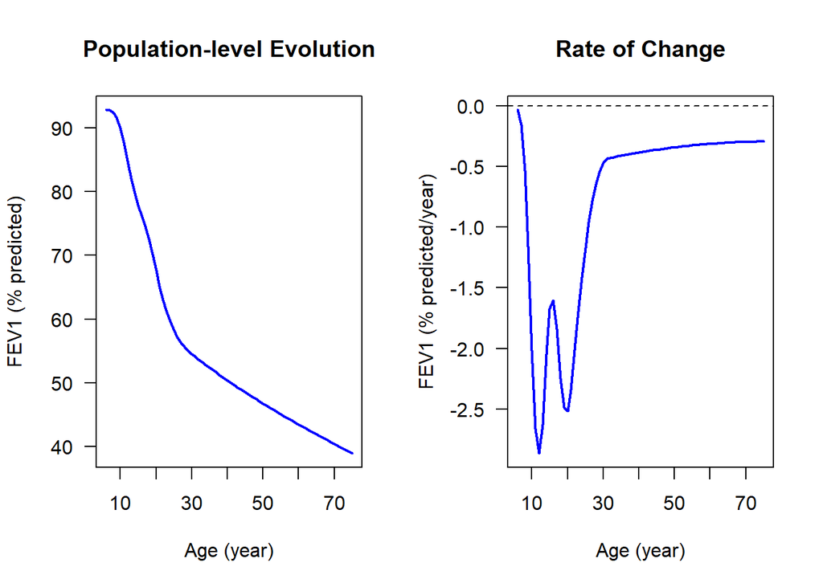

### 2.3.4 Model Diagnostics

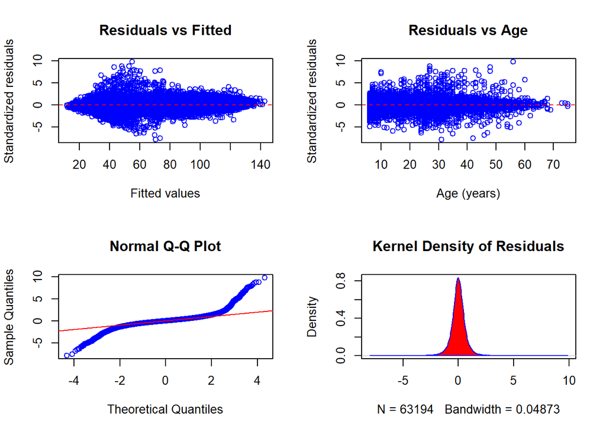

## 2.4 Linear Random Intercepts with Exponential Correlation

### 2.4.1 Assumptions

Average evolution: A linear mean evolution is assumed over time.

Patient-specific evolution: A linear evolution is assumed over time. We assume that each patient may start from a different time point but all patients have the same evolution over time. Correlation structure: exponential correlation function. This means that, for each subject, the correlation of FEV1 exponentially decays to zero with the distance between times (ages).

### 2.4.2 Model Estimation

```
## [1] "AIC =  511297"
```

```
## [1] "BIC =  511360"
```

Variance Components

|  | StdDev |
| --- | --- |
| (Intercept) | 0.1393125 |
| Residual | 22.5214028 |

```
## Correlation Structure: Exponential spatial correlation
##  Formula: ~Age | eDWID
##  Parameter estimate(s):
##        range       nugget
## 1.245185e+01 3.170311e-13
```

|  | Value | Std.Error | DF | t-value | p-value |
| --- | --- | --- | --- | --- | --- |
| (Intercept) | 97.950 | 0.249 | 32382 | 393.521 | 0 |
| Age | -1.363 | 0.012 | 32382 | -115.951 | 0 |
| Age_Diag | 0.611 | 0.033 | 30809 | 18.328 | 0 |

As the estimation of the coefficient for ‘Age’ is around -1.363 % predicted/year, this means for one year increase in age, FEV1 is decreasing by 1.363 (unit % predicted).

### 2.4.3 Model Inference

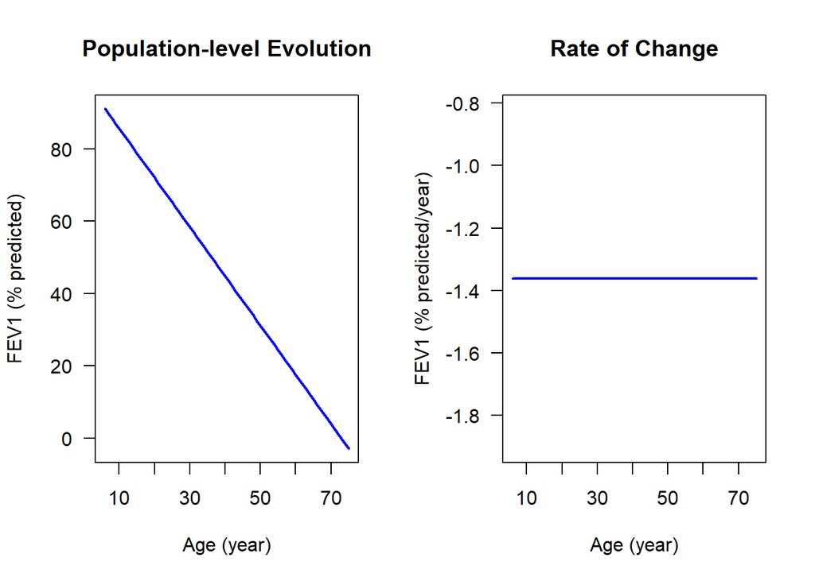

### 2.4.4 Model Diagnostics

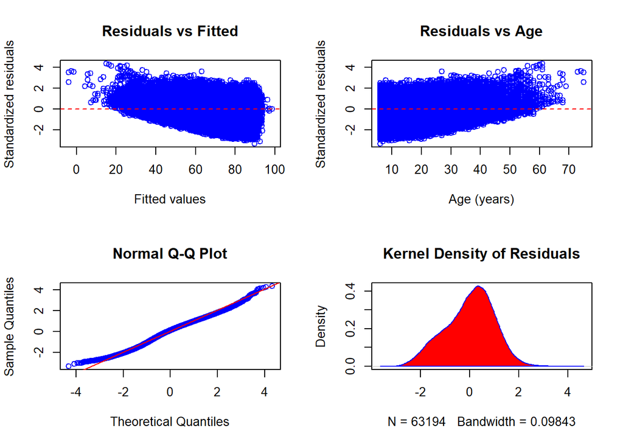

Based on the above model diagnostics plots, this model seems more appropriate to this data set than the previous LME models. There is less evidence of non-constant variance based on the residual plots. The Q-Q plotand the Kernel density plot indicate that the residuals are approximately normally distributed with a bit heavier tail.

## 2.5 Spline Random Intercept with Exponential Correlation

### 2.5.1 Assumptions

Average evolution: A non-linear evolution (assuming cubic natural splines) is assumed over time.

Patient-specific evolution: A linear evolution is assumed over time and each patient may start at different time point

Correlation structure: exponential correlation function. This means that, for each subject, the correlation of FEV1 exponentially decays to zero with the distance between times (age).

### 2.5.2 Model Estimation

```
## [1] "Knots location (at age): 9.8, 13.5, 17.3, 21.4, 31.3"
```

```
## [1] "AIC =  509569"
```

```
## [1] "BIC =  509678"
```

Variance Components

|  | StdDev |
| --- | --- |
| (Intercept) | 0.5286845 |
| Residual | 21.9880989 |

```
## Correlation Structure: Exponential spatial correlation
##  Formula: ~Age | eDWID
##  Parameter estimate(s):
##        range       nugget
## 1.193057e+01 3.028916e-20
```

|  | Value | Std.Error | DF | t-value | p-value |
| --- | --- | --- | --- | --- | --- |
| (Intercept) | 91.159 | 0.279 | 32377 | 326.161 | 0 |
| ns1 | -13.261 | 0.465 | 32377 | -28.536 | 0 |
| ns2 | -17.530 | 0.476 | 32377 | -36.838 | 0 |
| ns3 | -34.709 | 0.509 | 32377 | -68.142 | 0 |
| ns4 | -44.629 | 1.123 | 32377 | -39.737 | 0 |
| ns5 | -50.092 | 1.550 | 32377 | -32.316 | 0 |
| ns6 | -54.999 | 3.245 | 32377 | -16.949 | 0 |
| Age_Diag | 0.618 | 0.033 | 30809 | 18.873 | 0 |

### 2.5.3 Model Inference

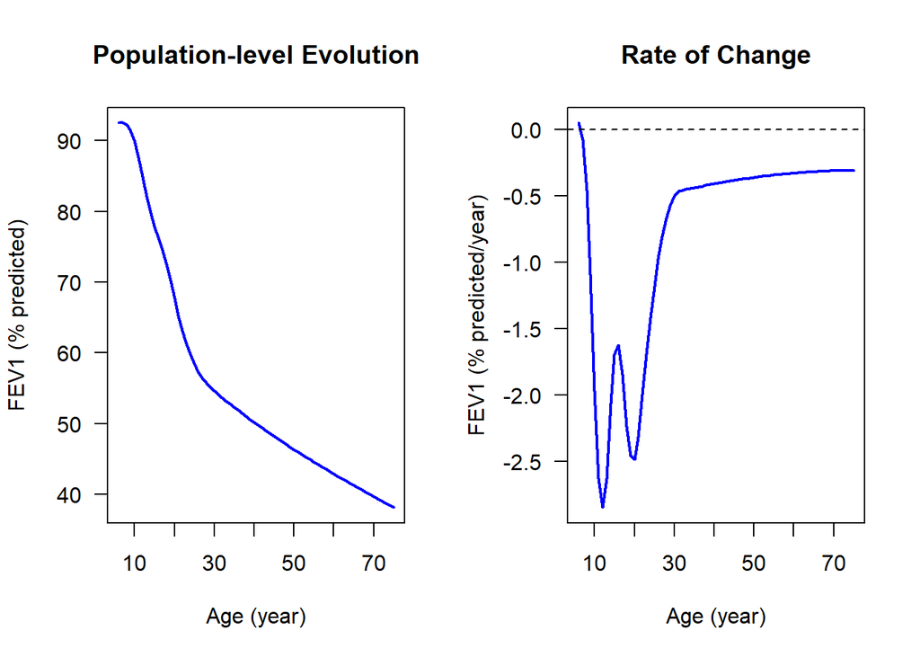

### 2.5.4 Model Diagnostics

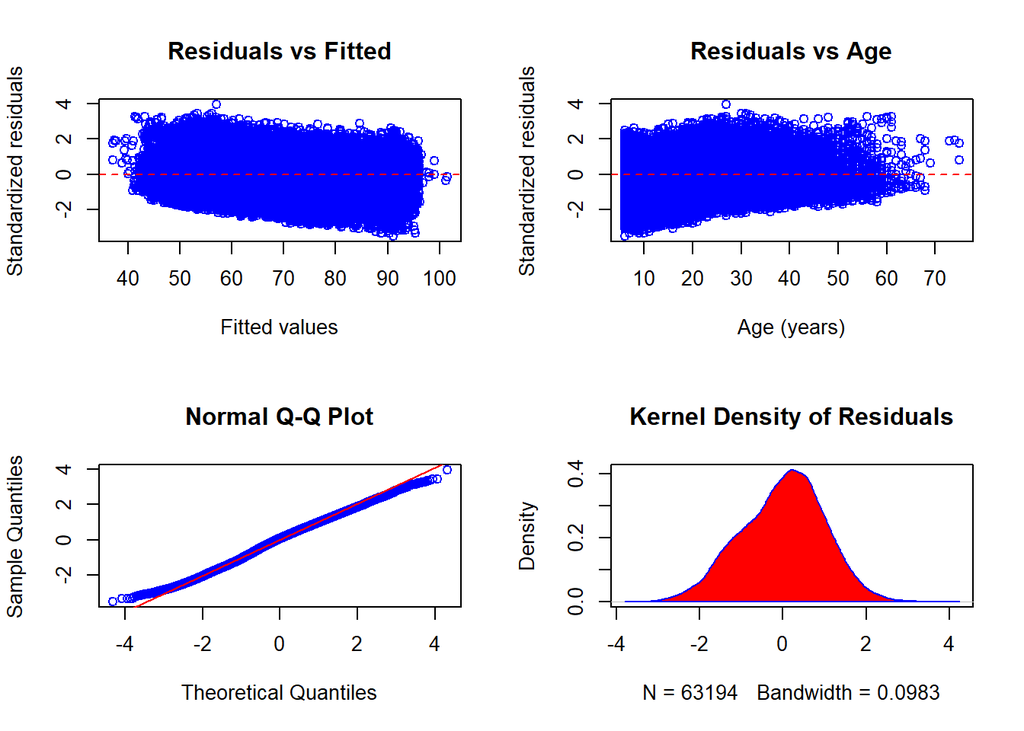

# 3 Linear Generalized Estimating Equations Model (GEE)

Compared with LME models, GEE models allow for weaker distributional assumptions and are more robust to covariance misspecification. In this analysis, the average evolution (fixed-effects) structure in the GEE model was selected based on the performance of all LME models. This GEE model is fitted with a linear structure to model the mean evolution and accounts for longitudinal correlation using the sandwich estimator.

## 3.1 Assumptions

Patient-specific evolution: A linear evolution is assumed over time and each patient may start at different time point.

Correlation structure: independence (working) correlation function.

## 3.2 Model Estimation

Coefficients:

|  | Estimate | Std.err | Wald | Pr(>\|W\|) |
| --- | --- | --- | --- | --- |
| (Intercept) | 98.704 | 0.251 | 154248.523 | 0 |
| Age | -1.408 | 0.013 | 11442.343 | 0 |
| Age_Diag | 0.611 | 0.034 | 322.928 | 0 |

Estimated Scale Parameters:

|  | Estimate | Std.err |
| --- | --- | --- |
| (Intercept) | 504.777 | 3.831 |

## 3.3 Model Inference

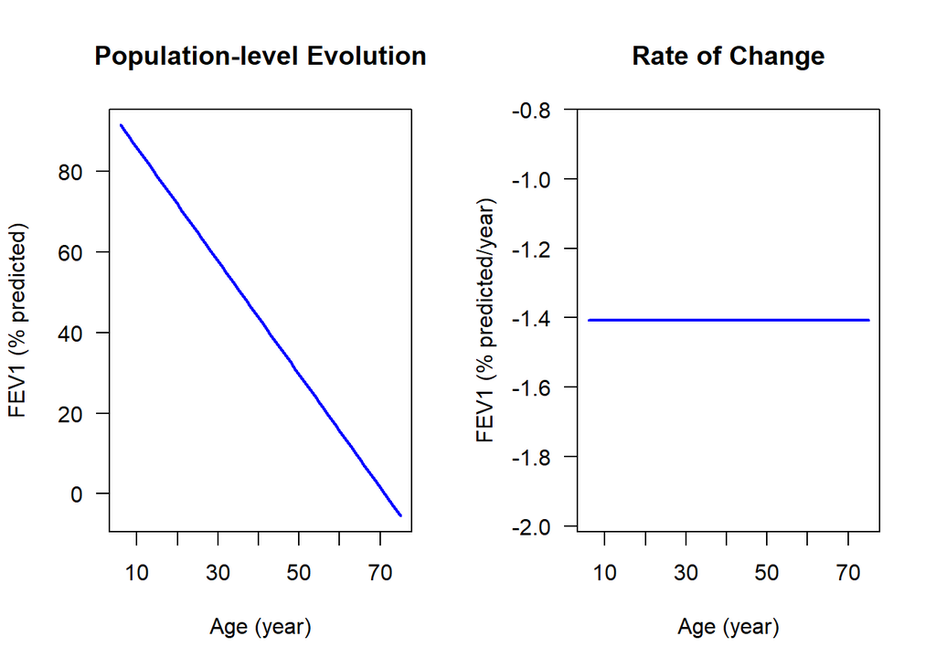

## 3.4 Model Diagnostics

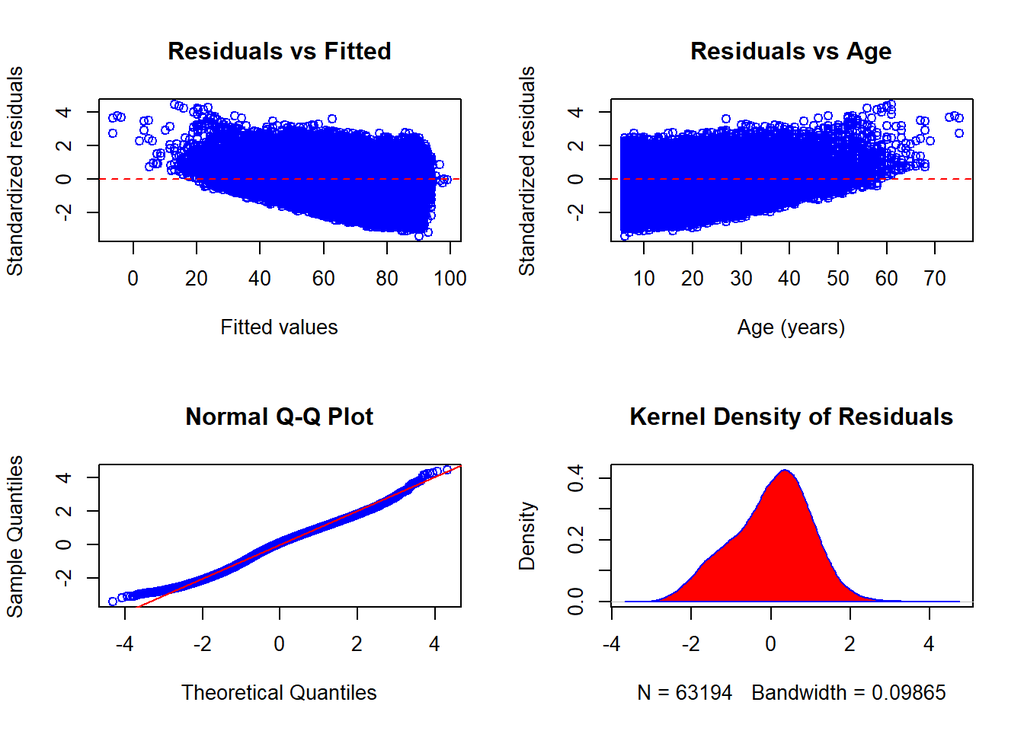

Based on the above model diagnostics plots, the GEE model seems more appropriate to our data set than the LME models considered previously. There is less evidence of non-constant variance based on the residual plots. The Q-Q plot shows that residuals approximate the unit normal distribution, which suggests that the relaxed assumptions alleviate issues with heavy tails. The kernel density plot also indicates that the model fit has improved by using GEE.

# 4 Non-linear Generalized Estimating Equations Model (GEE)

In this analysis, the GEE mode is fitted with a spline structure to model the mean evolution and includes an independence correlation.

## 4.1 Assumptions

Average evolution: A non-linear evolution (assuming cubic natural splines) is used over time.

Patient-specific evolution: A linear evolution is assumed over time and each patient may start at different time point.

Correlation structure: independence correlation function (sandwich estimator used to account for longitudinal correlation).

## 4.2 Model Estimation

Coefficients:

|  | Estimate | Std.err | Wald | Pr(>\|W\|) |
| --- | --- | --- | --- | --- |
| (Intercept) | 93.326 | 0.332 | 78908.995 | 0 |
| ns1 | -15.640 | 0.625 | 626.785 | 0 |
| ns2 | -21.264 | 0.699 | 924.876 | 0 |
| ns3 | -37.112 | 0.663 | 3134.206 | 0 |
| ns4 | -46.102 | 1.400 | 1083.899 | 0 |
| ns5 | -55.543 | 1.911 | 844.426 | 0 |
| ns6 | -57.737 | 3.981 | 210.359 | 0 |
| Age_Diag | 0.642 | 0.034 | 357.205 | 0 |

Estimated Scale Parameters:

|  | Estimate | Std.err |
| --- | --- | --- |
| (Intercept) | 479.844 | 3.622 |

## 4.3 Model Inference

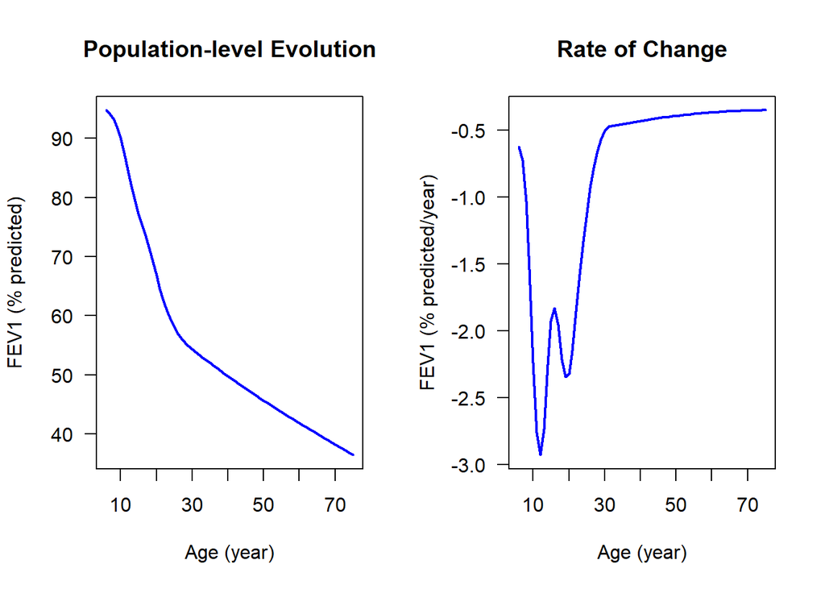

## 4.4 Model Diagnostics

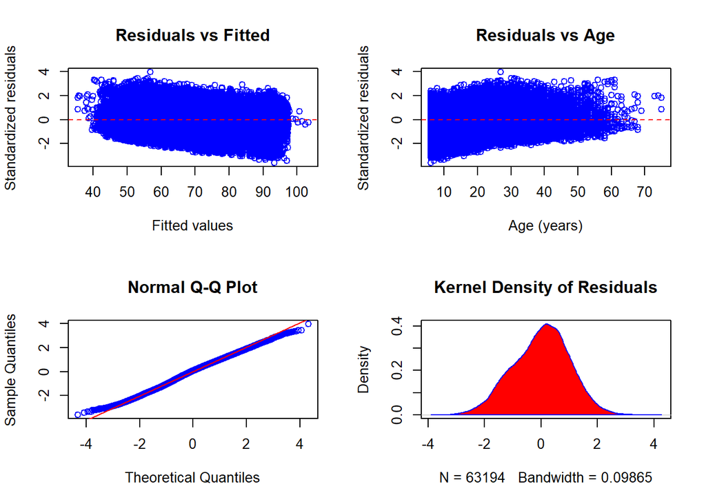

# 5 Plot Population-level FEV1 (% predicted) Estimation for All Models

| Model Name Abbreviation Name | Model Name Abbreviation Specification |
| --- | --- |
| Int | Linear evolution with random intercept |
| Int + Slope | Linear evolution with random intercept and slope |
| Spline | Non-linear evolution by using spline as both average evolution and random effect |
| Int + Corr | Linear evolution with random intercept and exponential correlation structure |
| Spline + Corr | Non-linear evolution with spline as average evolution, random intercept and exponential correlation structure |
| Lin_GEE | Linear evolution with independence correlation structure |
| Nonlin_GEE | Non-linear evolution by using spline with independence correlation structure |

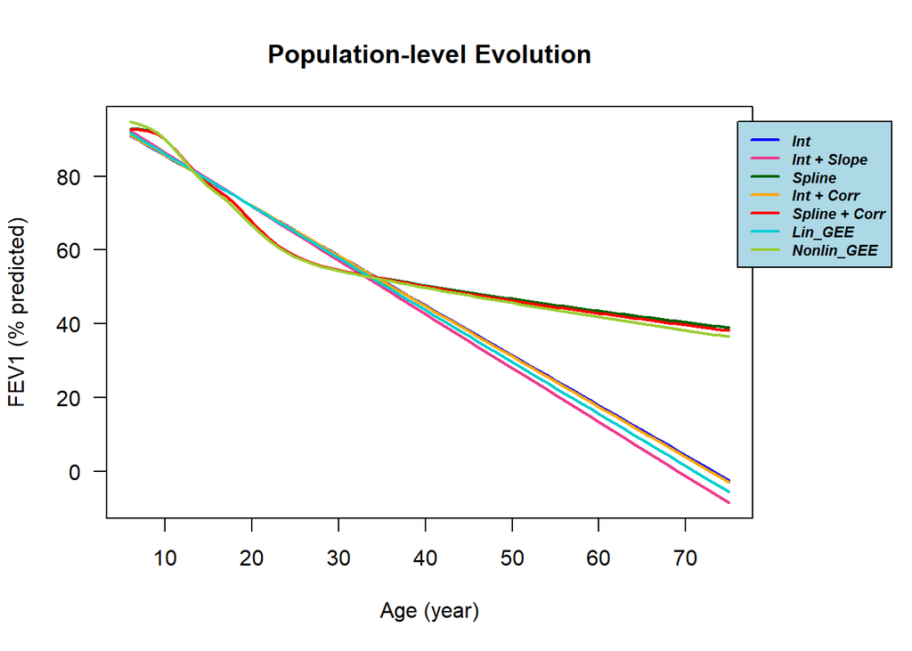

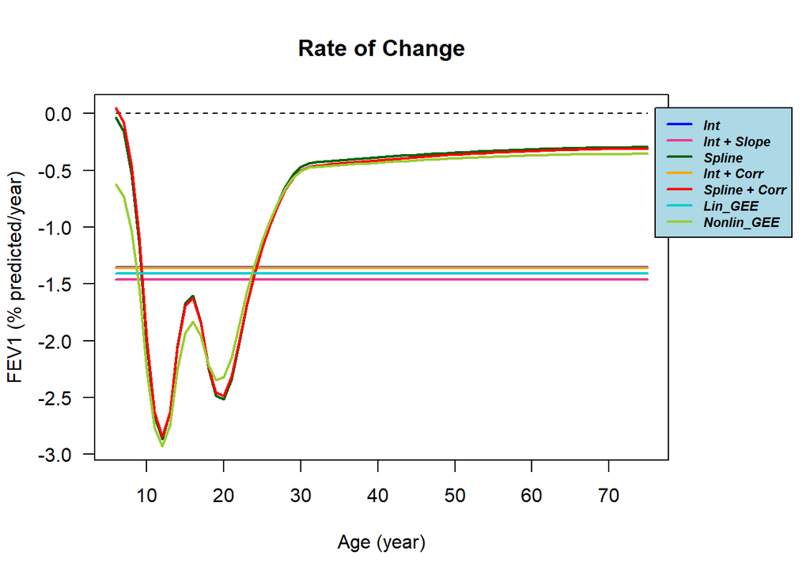

To check more closely, we zoom in the result for age 6 to 30.

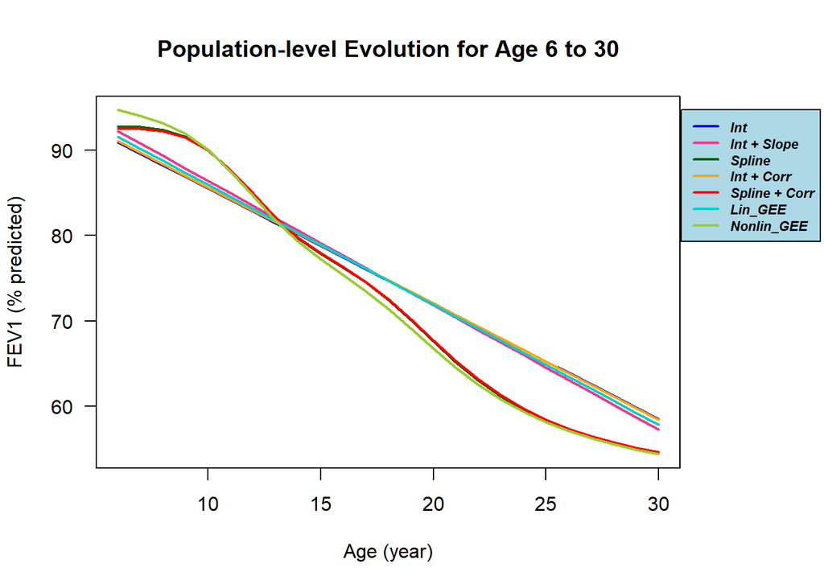

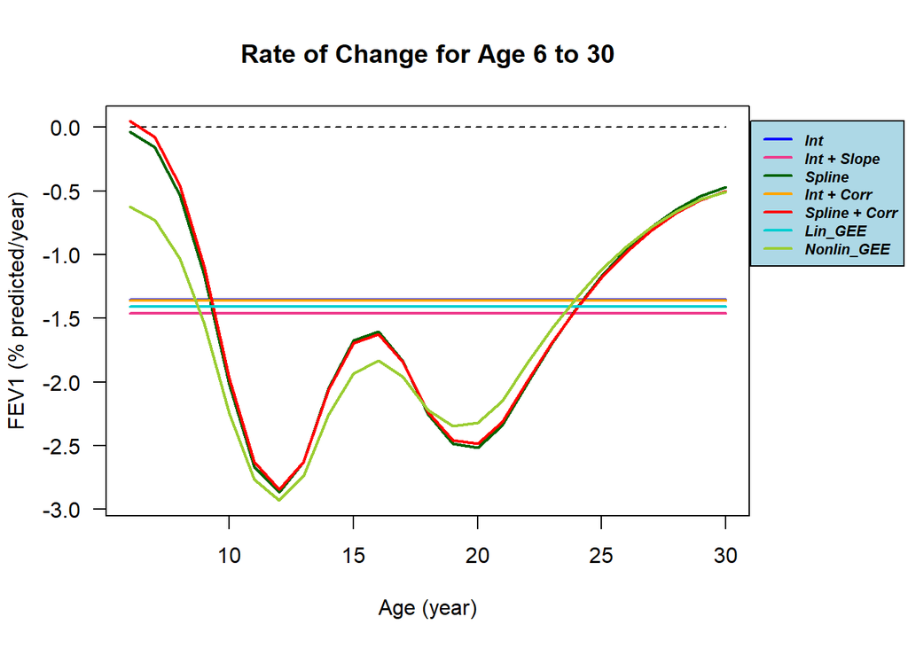